# ANLY512 : Data Visualilzation

4/22/2019

## Introduction

Climate change and science has been an issue for discussion and debate for at least the last decade. Climate data collection is currently being collected for areas all over the world. Policy decisions are based on the most recent analysis conducted on data extracted from huge online repositories of this data. Due to the inherent growth in the electronic production and storage of information, there is often a feeling of “information overload” or inundation when facing the process of quantitative decision making.

The ability to synthesize large data sets using visualizations is a skill that all data scientists should have. In addition to this data, scientists are called upon to present data syntheses and develop questions or ideas based on their data exploration.

## Objective

The objective of this laboratory is to survey the available data, plan, design, and create an information dashboard/presentation that not only explores the data but also develops questions based on that data exploration. To accomplish this task, the following process needs to be completed:

- Identify what information interests you about climate change.
- Find, collect, organize, and summarize the data necessary to create your data exploration plan.
- Design and create the most appropriate visualizations to explore the data and present that information. (no less than 5)
- Organize the layout of those visualizations into a dashboard in a way that shows your path of data exploration.
- Develop four questions or ideas about climate change from your visualizations.

## Data and Research Background

##### **Data 1** : *Northern Hemisphere Sea Ice Extent (1979 - 2019)*

##### **Data 2** : *Northern Hemisphere Ocean Temperature Anomalies (1979 - 2019)*

*National Center For Environmental Information https://www.ncdc.noaa.gov/*

Both the level/amount of sea ice and the atmospheric temperature anomalies are quite important factors of climate change especially global warming. I specifically use these two types of data, two seasons from each year, four compact data sets in total.

- February Sea Ice Data
- August Sea Ice Data
- February Temperature Anomalies Data
- August Temperature Anomalies Data

## Analysis & Visualization 1

I will perform visualizations and analyses in 3 parts; (1). Sea Ice data, (2). Temperature Anomalies data, and (3). Relationships between them.

Before jumping in to analysis, let’s take a look at Sea Ice coverage images with ggplot. The following is generated for the North Pole sea ice coverage in August 1979.

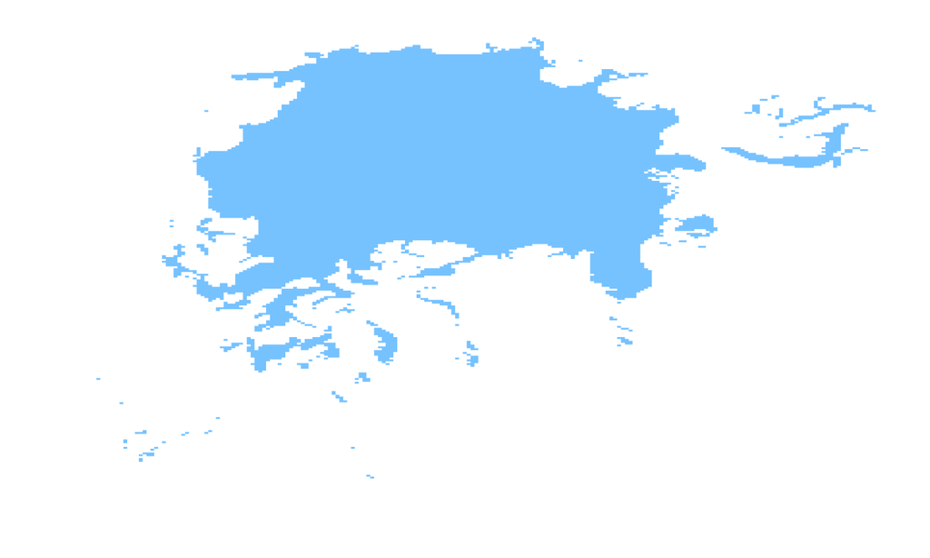

## Analysis & Visualization 2

Here is the same image for August 2018.

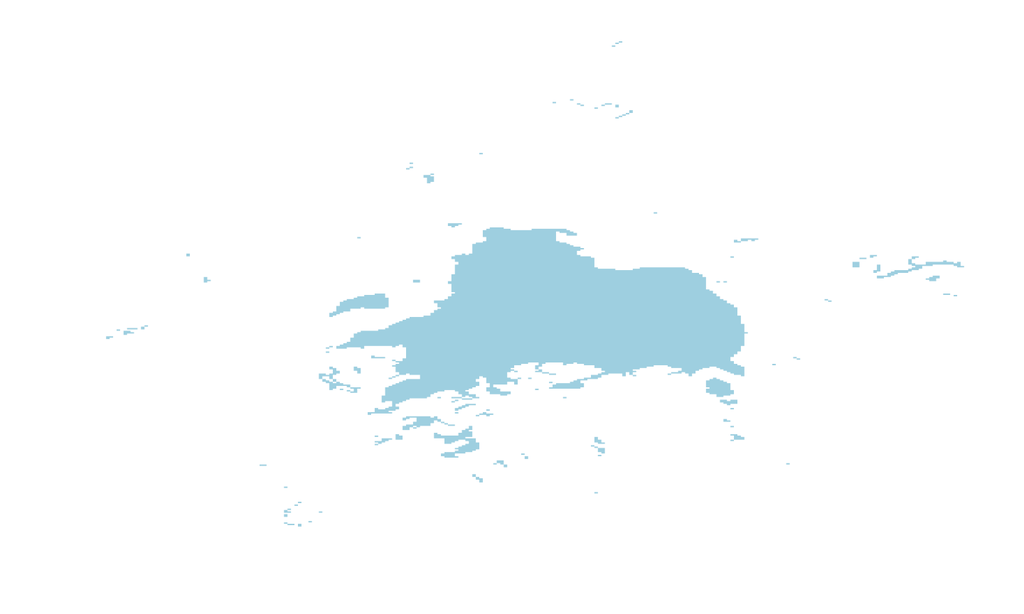

## Sea Ice in February 1

First, I will plot the sea ice level change in February as the sea ice level change in winter time, from 1979 to 2019 with line plot with regression line, followed by the summary of the date set.

```
## Classes 'tbl_df', 'tbl' and 'data.frame':    41 obs. of  3 variables:
##  $ Date   : int  1979 1980 1981 1982 1983 1984 1985 1986 1987 1988 ...
##  $ Value  : num  16.2 16 15.6 16 16 ...
##  $ Anomaly: num  0.88 0.66 0.3 0.67 0.71 0 0.17 0.48 0.75 0.28 ...
##  - attr(*, "spec")=List of 2
##   ..$ cols   :List of 3
##   .. ..$ Date   : list()
##   .. .. ..- attr(*, "class")= chr  "collector_integer" "collector"
##   .. ..$ Value  : list()
##   .. .. ..- attr(*, "class")= chr  "collector_double" "collector"
##   .. ..$ Anomaly: list()
##   .. .. ..- attr(*, "class")= chr  "collector_double" "collector"
##   ..$ default: list()
##   .. ..- attr(*, "class")= chr  "collector_guess" "collector"
##   ..- attr(*, "class")= chr "col_spec"
```

## Sea Ice in February 2

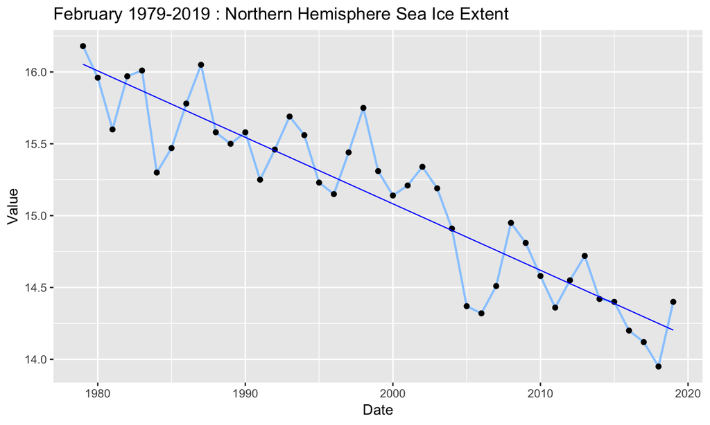

## Sea Ice in February 3

The line plot above tells that the sea ice level in winter time is decreasing from 16.18 million km^2 to 14.40 million km^2. The added regression line confirms the decrease with a negative slope.

```
##
## Call:
## lm(formula = ice2$Value ~ ice2$Date)
##
## Coefficients:
## (Intercept)    ice2$Date
##   107.60841     -0.04626
```

```
##
## Call:
## lm(formula = ice2$Value ~ ice2$Date)
##
## Residuals:
##      Min       1Q   Median       3Q      Max
## -0.52248 -0.14206  0.01278  0.18146  0.57520
##
## Coefficients:
##               Estimate Std. Error t value Pr(>|t|)
## (Intercept) 107.608406   6.559257   16.41   <2e-16 ***
## ice2$Date    -0.046263   0.003281  -14.10   <2e-16 ***
## ---
## Signif. codes:  0 '***' 0.001 '**' 0.01 '*' 0.05 '.' 0.1 ' ' 1
##
## Residual standard error: 0.2486 on 39 degrees of freedom
## Multiple R-squared:  0.836,  Adjusted R-squared:  0.8318
## F-statistic: 198.8 on 1 and 39 DF,  p-value: < 2.2e-16
```

## Sea Ice in August 1

```
## Classes 'tbl_df', 'tbl' and 'data.frame':    40 obs. of  3 variables:
##  $ Date   : int  1979 1980 1981 1982 1983 1984 1985 1986 1987 1988 ...
##  $ Value  : num  8.04 7.98 7.84 8.14 8.19 7.77 7.4 7.98 7.63 7.89 ...
##  $ Anomaly: num  0.84 0.78 0.64 0.94 0.99 0.57 0.2 0.78 0.43 0.69 ...
##  - attr(*, "spec")=List of 2
##   ..$ cols   :List of 3
##   .. ..$ Date   : list()
##   .. .. ..- attr(*, "class")= chr  "collector_integer" "collector"
##   .. ..$ Value  : list()
##   .. .. ..- attr(*, "class")= chr  "collector_double" "collector"
##   .. ..$ Anomaly: list()
##   .. .. ..- attr(*, "class")= chr  "collector_double" "collector"
##   ..$ default: list()
##   .. ..- attr(*, "class")= chr  "collector_guess" "collector"
##   ..- attr(*, "class")= chr "col_spec"
```

## Sea Ice in August 2

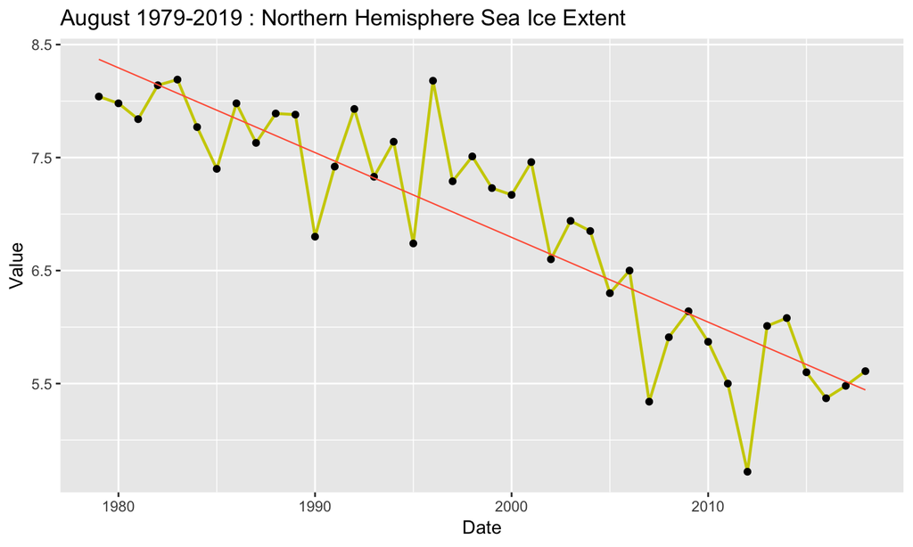

## Sea Ice in August 3

This line plot shows that the sea ice level in summer time is decreasing from 8.04 million km^2 to 5.61 million km^2. The added regression line has downward slope that indicates a negative linear relationship between the time and value as the plot for February.

```
##
## Call:
## lm(formula = ice8$Value ~ ice8$Date)
##
## Coefficients:
## (Intercept)    ice8$Date
##   156.81650     -0.07501
```

```
##
## Call:
## lm(formula = ice8$Value ~ ice8$Date)
##
## Residuals:
##      Min       1Q   Median       3Q      Max
## -1.17385 -0.23910  0.00338  0.28728  1.08597
##
## Coefficients:
##               Estimate Std. Error t value Pr(>|t|)
## (Intercept) 156.816497  12.176119   12.88 1.95e-15 ***
## ice8$Date    -0.075011   0.006093  -12.31 7.81e-15 ***
## ---
## Signif. codes:  0 '***' 0.001 '**' 0.01 '*' 0.05 '.' 0.1 ' ' 1
##
## Residual standard error: 0.4448 on 38 degrees of freedom
## Multiple R-squared:  0.7996, Adjusted R-squared:  0.7943
## F-statistic: 151.6 on 1 and 38 DF,  p-value: 7.81e-15
```

## Sea Ice Comparison

Let’s take a look at the two graphs in one panel. As the previous regression analyses clarified the slope of August is steeper than the February slope. Therefore, I can say that the sea ice melting speed August is faster than February’s.

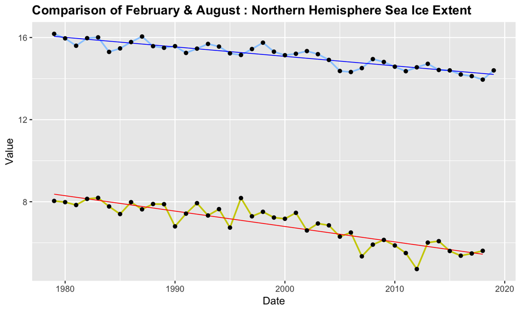

## Ocean Temperature Anomalies in February 1

Now, I will try visualizing the ocean temperature change as another indicator of global warming. Let’s take a look at February temperature anomalies as the change in winter time.

```
## Classes 'tbl_df', 'tbl' and 'data.frame':    41 obs. of  2 variables:
##  $ Year : int  1979 1980 1981 1982 1983 1984 1985 1986 1987 1988 ...
##  $ Value: num  0.06 0.22 0.16 0.18 0.16 0.11 -0.05 0.09 0.11 0.32 ...
##  - attr(*, "spec")=List of 2
##   ..$ cols   :List of 2
##   .. ..$ Year : list()
##   .. .. ..- attr(*, "class")= chr  "collector_integer" "collector"
##   .. ..$ Value: list()
##   .. .. ..- attr(*, "class")= chr  "collector_double" "collector"
##   ..$ default: list()
##   .. ..- attr(*, "class")= chr  "collector_guess" "collector"
##   ..- attr(*, "class")= chr "col_spec"
```

## Ocean Temperature Anomalies in February 2

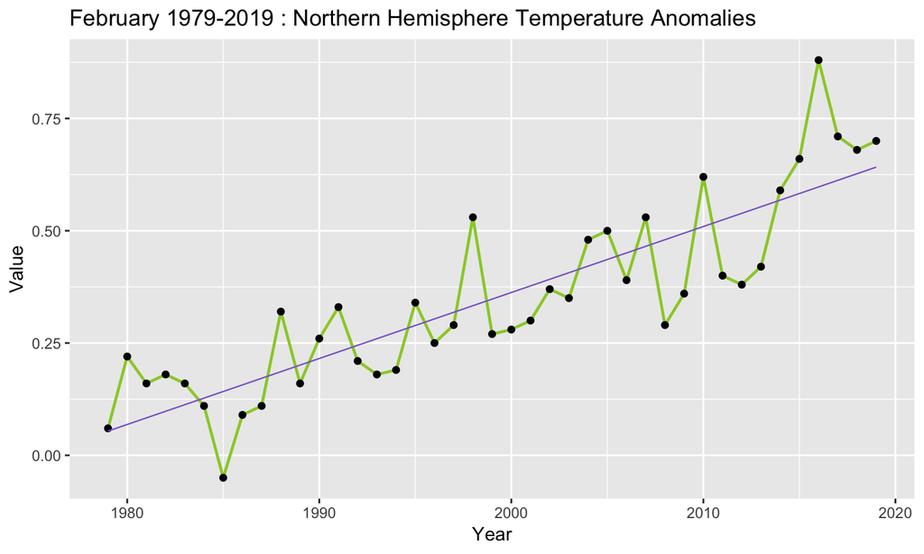

## Ocean Temperature Anomalies in February 3

```
##
## Call:
## lm(formula = ot2$Value ~ ot2$Year)
##
## Coefficients:
## (Intercept)     ot2$Year
##   -29.02426      0.01469
```

```
##
## Call:
## lm(formula = ot2$Value ~ ot2$Year)
##
## Residuals:
##      Min       1Q   Median       3Q      Max
## -0.19210 -0.07719 -0.01740  0.06465  0.28241
##
## Coefficients:
##               Estimate Std. Error t value Pr(>|t|)
## (Intercept) -29.024261   2.800234  -10.37 9.18e-13 ***
## ot2$Year      0.014693   0.001401   10.49 6.50e-13 ***
## ---
## Signif. codes:  0 '***' 0.001 '**' 0.01 '*' 0.05 '.' 0.1 ' ' 1
##
## Residual standard error: 0.1061 on 39 degrees of freedom
## Multiple R-squared:  0.7383, Adjusted R-squared:  0.7316
## F-statistic:   110 on 1 and 39 DF,  p-value: 6.501e-13
```

## Ocean Temperature Anomalies in August 1

Next, let’s consider August ocean temperature anomalies as the temperature change in summer time.

```
## Classes 'tbl_df', 'tbl' and 'data.frame':    40 obs. of  2 variables:
##  $ Year : int  1979 1980 1981 1982 1983 1984 1985 1986 1987 1988 ...
##  $ Value: num  0.17 0.18 0.12 0.05 0.13 0.04 -0.04 0.11 0.34 0.23 ...
##  - attr(*, "spec")=List of 2
##   ..$ cols   :List of 2
##   .. ..$ Year : list()
##   .. .. ..- attr(*, "class")= chr  "collector_integer" "collector"
##   .. ..$ Value: list()
##   .. .. ..- attr(*, "class")= chr  "collector_double" "collector"
##   ..$ default: list()
##   .. ..- attr(*, "class")= chr  "collector_guess" "collector"
##   ..- attr(*, "class")= chr "col_spec"
```

## Ocean Temperature Anomalies in August 2

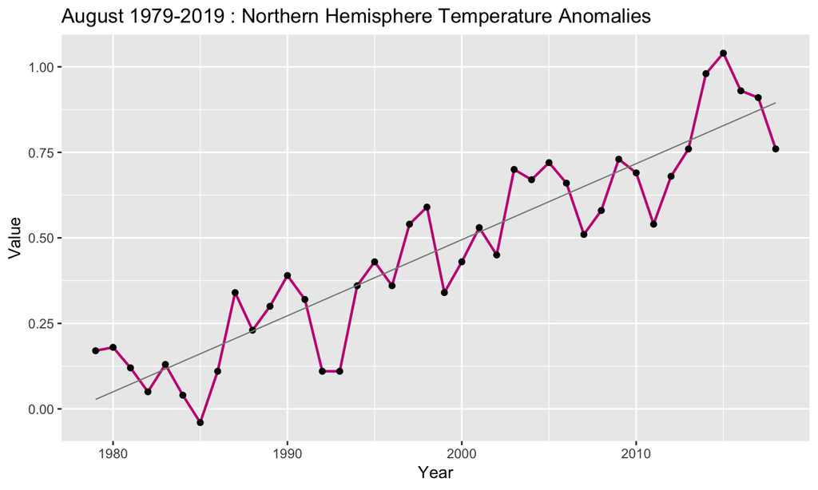

## Ocean Temperature Anomalies in August 3

```
##
## Call:
## lm(formula = ot8$Value ~ ot8$Year)
##
## Coefficients:
## (Intercept)     ot8$Year
##   -43.97632      0.02224
```

```
##
## Call:
## lm(formula = ot8$Value ~ ot8$Year)
##
## Residuals:
##      Min       1Q   Median       3Q      Max
## -0.22895 -0.08334  0.01328  0.09287  0.21186
##
## Coefficients:
##               Estimate Std. Error t value Pr(>|t|)
## (Intercept) -43.976316   3.179407  -13.83   <2e-16 ***
## ot8$Year      0.022235   0.001591   13.98   <2e-16 ***
## ---
## Signif. codes:  0 '***' 0.001 '**' 0.01 '*' 0.05 '.' 0.1 ' ' 1
##
## Residual standard error: 0.1161 on 38 degrees of freedom
## Multiple R-squared:  0.8372, Adjusted R-squared:  0.8329
## F-statistic: 195.4 on 1 and 38 DF,  p-value: < 2.2e-16
```

## Ocean Temperature Anomalies Comparison 1

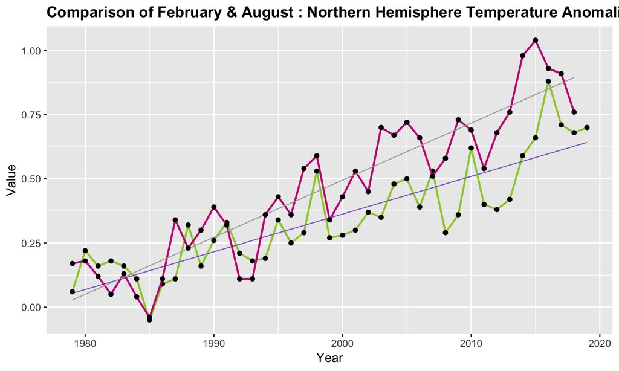

## Ocean Temperature Anomalies Comparison 2

They both have similar positive slopes, but the slope of August is slilghtly steeper than the February slope. Therefore, I can say that the temperature anomalies in August is more rapid than February’s.

## Relationship between Se Ice Extent & Ocean Temperature Anomalies 1

Now, I would like to check if there exists any interesting relationship between two data set types. It is kind of intuitive to predict that when the ocean temperature anomalies increases the sea ice level decreases, which is a principle definition of global warming.

```
## [1] -0.8155506
```

## Relationship between Se Ice Extent & Ocean Temperature Anomalies 2

The Pearson correlation test result indicates that there exists a slightly strong negative correlation between sea ice level and temperature anomalies.

## Relationship between Se Ice Extent & Ocean Temperature Anomalies 3

Let’s visualize the correlation with scatter plot.

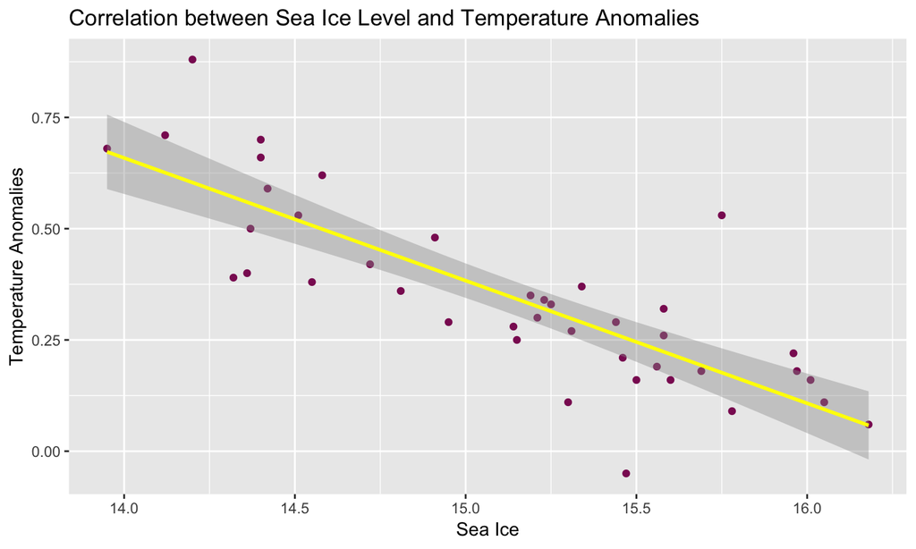

## Relationship between Se Ice Extent & Ocean Temperature Anomalies 4

From this scatter plot, we observe a nice linear correlation between two variables.

Let me check their normality by using Shapiro-W test, just to make sure.

```
##
##  Shapiro-Wilk normality test
##
## data:  comb2$Value.x
## W = 0.95615, p-value = 0.1152
```

## Relationship between Se Ice Extent & Ocean Temperature Anomalies 5

```
##
##  Shapiro-Wilk normality test
##
## data:  comb2$Value.y
## W = 0.96678, p-value = 0.2694
```

Their p-values are both greater than the significant level 0.05, therefore,they have normal distributions.

## Conclusion

By visualizing the four data sets with line/scatter plots, the following facts were confirmed;

- The sea ice level in northern hemisphere is decreasing very fast-paced in the last 40 years.
- The temperature anomalies in northern hemisphere is increasing pretty rapidly in the last 40 years.
- These two factors have a strong correlation.

## Questions & Ideas

1. What other types of visualization methods can be used/applied for this analysis? I was debating to use histogram or adding more factors to form a matrix plot.
2. What can we predict for southern hemisphere by looking at northern hemisphere data sets?
3. The topic is interesting enough to analyze further. Having many variables and analyze with various models would be fun.
4. The coding strategy could be so varied!